# Explanation Analysis

```r
explan_data <- read_delim("subject_explanations.csv",
    delim = ";", escape_double = FALSE, trim_ws = TRUE)
```

# 1 Data preparation

Note: Subjects’ explanations were coded in the last columns (the column names describe the coded criterion). 1 means that the coding criterion is (clearly) met, 0 that it isn’t.

```r
# turn explanation coding values into factors

explan_data <- tdata_long

explan_data$`Correct explanation` <- as.factor(explan_data$`Correct explanation`)

explan_data$`Unclear explanation` <- as.factor(explan_data$`Unclear explanation`)

explan_data$`explanation focusing on perspective of patient` <- as.factor(explan_data$`explanation focusing on perspective of patient`)

explan_data$`Inferred absence because of low feature base rate` <- as.factor(explan_data$`Inferred absence because of low feature base rate`)

explan_data$`Inferred absence of latent feature due to visibility` <- as.factor(explan_data$`Inferred absence of latent feature due to visibility`)
```

# 2 Explanation Analysis

Please note: reported below are proportion tests that didn’t apply Yate’s correction, but even if Yate’s correction were to be applied, it wouldn’t turn any of the significant results into non-significant results and vice versa. As whether or not Yate’s correction should be applied is debated, it was decided to report the tests without Yate’s continuity correction.

1. Proportions of subjects in each feature condition who gave (correct) explanations for why the answer is 50:50

```r
# create a summary dataset that also contains the percentages
plotdata_between <- explan_data %>%
  group_by(dv_query, `Correct explanation`) %>%
  summarize(n = n()) %>%
  mutate(pct = n/sum(n),
         lbl = scales::percent(pct))


plotdata_between
```

```
## # A tibble: 6 × 5
## # Groups:   dv_query [3]
##   dv_query           `Correct explanation`     n   pct lbl
##   <fct>              <fct>                 <int> <dbl> <chr>
## 1 probability        0                        71 0.296 30%
## 2 probability        1                       169 0.704 70%
## 3 satisfaction_would 0                       117 0.488 48.8%
## 4 satisfaction_would 1                       123 0.512 51.2%
## 5 satisfaction_is    0                       101 0.421 42%
## 6 satisfaction_is    1                       139 0.579 58%
```

```r
plotdata_sub <- subset(plotdata_between, `Correct explanation` == 1)
```

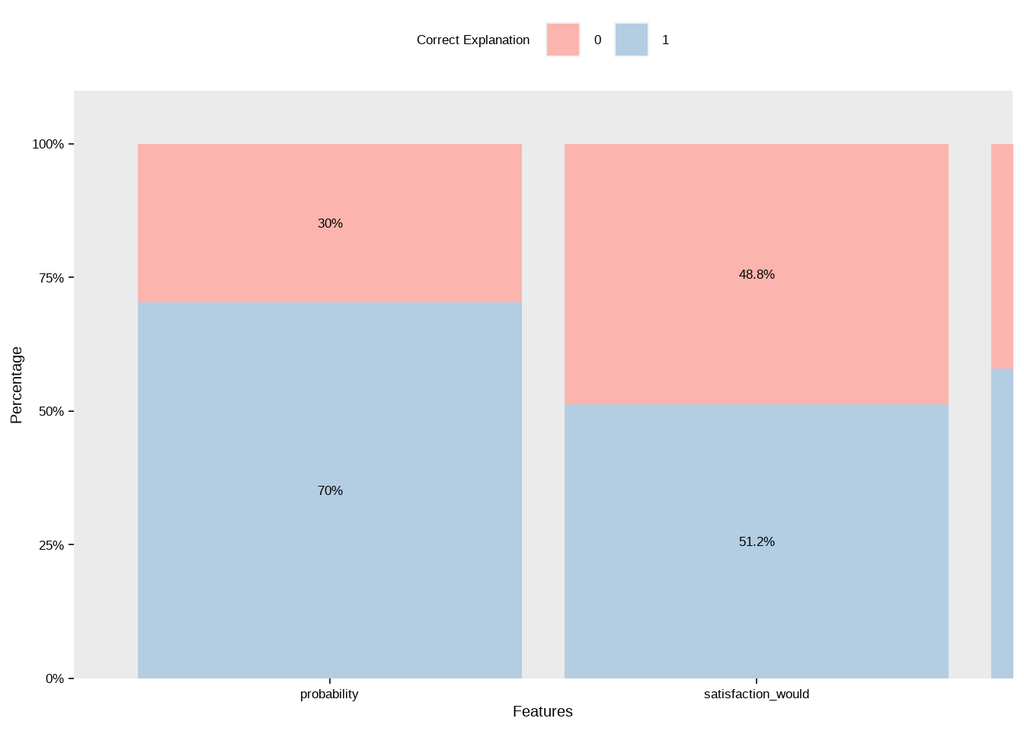

```r
plotdata <- plotdata_between

g<- ggplot(plotdata,
       aes(x = dv_query,
           y = pct,
           fill = `Correct explanation`)) +
  #facet_grid( ~ Features)+
  geom_bar(stat = "identity",
           position = "fill") +
  scale_y_continuous(limits = seq(0, 2),
                     breaks = seq(0, 1, .25),
                     expand = c(0,0),
                     label = percent) +
  #scale_x_discrete(labels = c("not \nmentioned", "'you don't \nknow'"))+
  coord_cartesian(xlim =c(1, 2), ylim = c(0, 1.1))+
  #coord_cartesian(clip = "off")+
  geom_text(aes(label = lbl),
            size = 4.5,
            position = position_stack(vjust = 0.5)) +
  scale_fill_brewer(palette = "Pastel1") +
  labs(y = "Percentage",
       fill = "Correct Explanation",
       x = "Features")+
  theme(legend.position = "top", axis.title = element_text(size = 15), axis.text = element_text(size = 13, color = "black"),
        legend.text = element_text(size = 13),legend.title = element_text(size = 13))+
  theme(panel.grid.major = element_blank(), panel.grid.minor = element_blank())

g
```

probability vs. satisfaction_would

```r
prop.test(x = c(plotdata$n[2], plotdata$n[4]), n = c(240, 240), alternative = "two.sided", correct = F)
```

```
##
##  2-sample test for equality of proportions without continuity correction
##
## data:  c(plotdata$n[2], plotdata$n[4]) out of c(240, 240)
## X-squared = 18.502, df = 1, p-value = 1.697e-05
## alternative hypothesis: two.sided
## 95 percent confidence interval:
##  0.1060317 0.2773016
## sample estimates:
##    prop 1    prop 2
## 0.7041667 0.5125000
```

probability vs. satisfaction_is

```r
prop.test(x = c(plotdata$n[2], plotdata$n[6]), n = c(240, 240), alternative = "two.sided", correct = F)
```

```
##
##  2-sample test for equality of proportions without continuity correction
##
## data:  c(plotdata$n[2], plotdata$n[6]) out of c(240, 240)
## X-squared = 8.1546, df = 1, p-value = 0.004295
## alternative hypothesis: two.sided
## 95 percent confidence interval:
##  0.03993811 0.21006189
## sample estimates:
##    prop 1    prop 2
## 0.7041667 0.5791667
```

satisfaction_is vs. satisfaction would

```r
prop.test(x = c(plotdata$n[4], plotdata$n[6]), n = c(240, 240), alternative = "less", correct = F)
```

```
##
##  2-sample test for equality of proportions without continuity correction
##
## data:  c(plotdata$n[4], plotdata$n[6]) out of c(240, 240)
## X-squared = 2.1514, df = 1, p-value = 0.07122
## alternative hypothesis: less
## 95 percent confidence interval:
##  -1.000000000  0.007926462
## sample estimates:
##    prop 1    prop 2
## 0.5125000 0.5791667
```

2. Proportions of subjects in the different dv_query conditions whose explanation indicated that they were taking the perspective of the patient into account instead of answering which explanation is more likely

```r
# create a summary dataset that also contains the percentages
plotdata_between <- explan_data %>%
  group_by(dv_query, `explanation focusing on perspective of patient`) %>%
  summarize(n = n()) %>%
  mutate(pct = n/sum(n),
         lbl = scales::percent(pct))


plotdata_between
```

```
## # A tibble: 5 × 5
## # Groups:   dv_query [3]
##   dv_query           explanation focusing on perspective of…¹     n    pct lbl
##   <fct>              <fct>                                    <int>  <dbl> <chr>
## 1 probability        0                                          240 1      100%
## 2 satisfaction_would 0                                          208 0.867  87%
## 3 satisfaction_would 1                                           32 0.133  13%
## 4 satisfaction_is    0                                          227 0.946  95%
## 5 satisfaction_is    1                                           13 0.0542 5%
## # … with abbreviated variable name
## #   ¹`explanation focusing on perspective of patient`
```

```r
plotdata_sub <- subset(plotdata_between, `explanation focusing on perspective of patient` == 1)
```

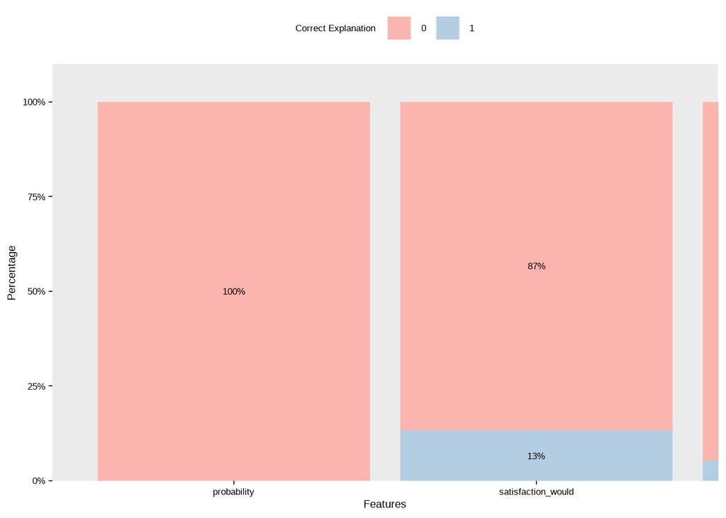

```r
plotdata <- plotdata_between

g<- ggplot(plotdata,
       aes(x = dv_query,
           y = pct,
           fill = `explanation focusing on perspective of patient`)) +
  #facet_grid( ~ Features)+
  geom_bar(stat = "identity",
           position = "fill") +
  scale_y_continuous(limits = seq(0, 2),
                     breaks = seq(0, 1, .25),
                     expand = c(0,0),
                     label = percent) +
  #scale_x_discrete(labels = c("not \nmentioned", "'you don't \nknow'"))+
  coord_cartesian(xlim =c(1, 2), ylim = c(0, 1.1))+
  #coord_cartesian(clip = "off")+
  geom_text(aes(label = lbl),
            size = 4.5,
            position = position_stack(vjust = 0.5)) +
  scale_fill_brewer(palette = "Pastel1") +
  labs(y = "Percentage",
       fill = "Correct Explanation",
       x = "Features")+
  theme(legend.position = "top", axis.title = element_text(size = 15), axis.text = element_text(size = 13, color = "black"),
        legend.text = element_text(size = 13),legend.title = element_text(size = 13))+
  theme(panel.grid.major = element_blank(), panel.grid.minor = element_blank())

g
```

```r
prop.test(x = c(0, plotdata$n[3]), n = c(240, 240), alternative = "less", correct = F)
```

```
##
##  2-sample test for equality of proportions without continuity correction
##
## data:  c(0, plotdata$n[3]) out of c(240, 240)
## X-squared = 34.286, df = 1, p-value = 2.379e-09
## alternative hypothesis: less
## 95 percent confidence interval:
##  -1.00000000 -0.09724083
## sample estimates:
##    prop 1    prop 2
## 0.0000000 0.1333333
```

```r
prop.test(x = c(0, plotdata$n[5]), n = c(240, 240), alternative = "less", correct = F)
```

```
##
##  2-sample test for equality of proportions without continuity correction
##
## data:  c(0, plotdata$n[5]) out of c(240, 240)
## X-squared = 13.362, df = 1, p-value = 0.0001284
## alternative hypothesis: less
## 95 percent confidence interval:
##  -1.00000000 -0.03013439
## sample estimates:
##     prop 1     prop 2
## 0.00000000 0.05416667
```

satisfaction_would vs. satisfaction_is

```r
prop.test(x = c(plotdata$n[3], plotdata$n[5]), n = c(240, 240), alternative = "greater", correct = F)
```

```
##
##  2-sample test for equality of proportions without continuity correction
##
## data:  c(plotdata$n[3], plotdata$n[5]) out of c(240, 240)
## X-squared = 8.8521, df = 1, p-value = 0.001464
## alternative hypothesis: greater
## 95 percent confidence interval:
##  0.03580517 1.00000000
## sample estimates:
##     prop 1     prop 2
## 0.13333333 0.05416667
```

3. proportions of subjects who inferred the absence of the unobserved feature due to its low overall probability (inferred evidence account)

```r
# create a summary dataset that also contains the percentages
plotdata_between <- explan_data %>%
  group_by(dv_query, `Inferred absence because of low feature base rate`) %>%
  summarize(n = n()) %>%
  mutate(pct = n/sum(n),
         lbl = scales::percent(pct))


plotdata_between
```

```
## # A tibble: 6 × 5
## # Groups:   dv_query [3]
##   dv_query           Inferred absence because of low featu…¹     n     pct lbl
##   <fct>              <fct>                                   <int>   <dbl> <chr>
## 1 probability        0                                         238 0.992   99%
## 2 probability        1                                           2 0.00833 1%
## 3 satisfaction_would 0                                         236 0.983   98%
## 4 satisfaction_would 1                                           4 0.0167  2%
## 5 satisfaction_is    0                                         235 0.979   98%
## 6 satisfaction_is    1                                           5 0.0208  2%
## # … with abbreviated variable name
## #   ¹`Inferred absence because of low feature base rate`
```

```r
plotdata_sub <- subset(plotdata_between, `Inferred absence because of low feature base rate` == 1)
```

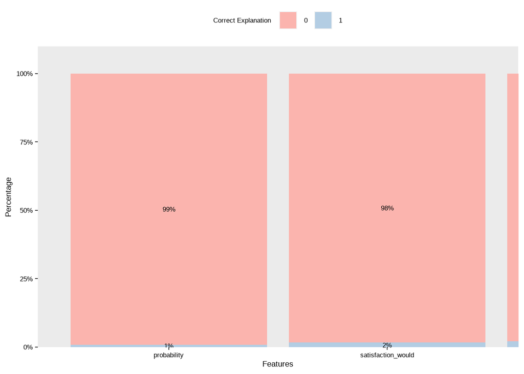

```r
plotdata <- plotdata_between

g<- ggplot(plotdata,
       aes(x = dv_query,
           y = pct,
           fill = `Inferred absence because of low feature base rate`)) +
  #facet_grid( ~ Features)+
  geom_bar(stat = "identity",
           position = "fill") +
  scale_y_continuous(limits = seq(0, 2),
                     breaks = seq(0, 1, .25),
                     expand = c(0,0),
                     label = percent) +
  #scale_x_discrete(labels = c("not \nmentioned", "'you don't \nknow'"))+
  coord_cartesian(xlim =c(1, 2), ylim = c(0, 1.1))+
  #coord_cartesian(clip = "off")+
  geom_text(aes(label = lbl),
            size = 4.5,
            position = position_stack(vjust = 0.5)) +
  scale_fill_brewer(palette = "Pastel1") +
  labs(y = "Percentage",
       fill = "Correct Explanation",
       x = "Features")+
  theme(legend.position = "top", axis.title = element_text(size = 15), axis.text = element_text(size = 13, color = "black"),
        legend.text = element_text(size = 13),legend.title = element_text(size = 13))+
  theme(panel.grid.major = element_blank(), panel.grid.minor = element_blank())

g
```

```r
prop.test(x = c(plotdata$n[2], plotdata$n[4]), n = c(240, 240), alternative = "two.sided", correct = F)
```

```
##
##  2-sample test for equality of proportions without continuity correction
##
## data:  c(plotdata$n[2], plotdata$n[4]) out of c(240, 240)
## X-squared = 0.67511, df = 1, p-value = 0.4113
## alternative hypothesis: two.sided
## 95 percent confidence interval:
##  -0.02819773  0.01153106
## sample estimates:
##      prop 1      prop 2
## 0.008333333 0.016666667
```

```r
prop.test(x = c(plotdata$n[2], plotdata$n[6]), n = c(240, 240), alternative = "two.sided", correct = F)
```

```
##
##  2-sample test for equality of proportions without continuity correction
##
## data:  c(plotdata$n[2], plotdata$n[6]) out of c(240, 240)
## X-squared = 1.3047, df = 1, p-value = 0.2533
## alternative hypothesis: two.sided
## 95 percent confidence interval:
##  -0.033919275  0.008919275
## sample estimates:
##      prop 1      prop 2
## 0.008333333 0.020833333
```

satisfaction_would vs. satisfaction_is

```r
prop.test(x = c(plotdata$n[4], plotdata$n[6]), n = c(240, 240), alternative = "two.sided", correct = F)
```

```
##
##  2-sample test for equality of proportions without continuity correction
##
## data:  c(plotdata$n[4], plotdata$n[6]) out of c(240, 240)
## X-squared = 0.11323, df = 1, p-value = 0.7365
## alternative hypothesis: two.sided
## 95 percent confidence interval:
##  -0.02843258  0.02009925
## sample estimates:
##     prop 1     prop 2
## 0.01666667 0.02083333
```